# Technology mediation in child sexual exploitation and abuse in Africa and Asia

Modelling script (complete case analysis)

Author

Ghai et al.

# Analysis Overview

To examine associations between demographic and socio-cultural factors and disclosure of technology-facilitated CSEA, we fit Bayesian multilevel logistic regression models using brms with survey weights. All analyses used complete-case with missing data.

**Model Specifications**

All models used Bernoulli family with logit link. We ran 4 chains with 2,000 iterations (1,000 warmup) using cmdstanr backend with adapt_delta=0.99. We assessed model fit using LOO-CV and Pareto-k diagnostics. For channel-specific models, we calculated events per variable (EPV) to assess statistical power.

```r
# Load packages
library(tidyverse)
library(brms)
library(posterior)
library(bayesplot)
library(bayestestR)
library(tidybayes)
library(marginaleffects)
library(loo)
library(patchwork)
library(survey)
library(srvyr)
library(knitr)
library(kableExtra)
library(gt)
library(gtsummary)
library(scales)
library(viridis)
library(colorspace)
library(RColorBrewer)
library(corrplot)
library(ggrepel)
library(ggdist)
library(ggh4x)
library(ggnewscale)
library(car)
library(performance)
library(broom.mixed)
library(mice)
library(janitor)
library(glue)
library(rlang)
library(rstan)

knitr::opts_chunk$set(dev = "png")

# Modelling: Always run brms with cmdstanr maybe with threading
dir.create("models", FALSE)
options(
  brms.backend = "cmdstanr",
  mc.cores = min(parallel::detectCores(), 8),
  brms.threads = parallel::detectCores() %/% 4
)

# Make plots pretty
theme_set(
  theme_linedraw() +
    theme(panel.grid = element_blank())
)

# Output options
opts_chunk$set(
  eval = TRUE,
  cache = TRUE,
  warning = FALSE,
  error = FALSE,
  message = FALSE,
  echo = knitr::is_html_output()
)
options(digits = 2)
ITER <- 2000
```

```r
d_victim <- d_victim %>%
  select(
    pid = CBU_ID,
    sex,
    age,
    presex,
    nindex,
    parentmediate,
    sexed,
    urbanrural,
    helpseeking,
    digitalskills,
    COUNTRY,
    wgt_scaled,
    victim,
    starts_with("toldnoone_"),
    starts_with("abuse_"),
    starts_with("police_"),
    starts_with("helpline_"),
    starts_with("teacher_"),
    starts_with("sworker_"),
    starts_with("friend_"),
    starts_with("sibling_"),
    starts_with("father_"),
    starts_with("mother_"),
    starts_with("other_"),
    starts_with("othera_")
  )

# Identical to function in 2a_disclosure.qmd
# d_report <- disclosure_data(d_victim)
```

## Define Labels

```r
# labels
channel_labels <- c(
  police   = "Police",
  helpline = "Helpline",
  sworker  = "Social Worker",
  teacher  = "Teacher",
  mother   = "Mother",
  father   = "Father",
  sibling  = "Sibling",
  friend   = "Friend",
  other    = "Other",
  othera   = "Other Adult"
)

# facet labels for predictors including variations (used throughout)
facet_labels <- c(
  "b_Intercept" = "Intercept",
  "b_sex1" = "Girl (vs Boy)",
  "b_sexGirl" = "Girl (vs Boy)",
  "sex1" = "Girl (vs Boy)",
  "sexGirl" = "Girl (vs Boy)",
  "b_age" = "Age (per year)",
  "age" = "Age (per year)",
  "b_presex1" = "Premarital sex",
  "presex1" = "Premarital sex",
  "b_nindex" = "Inequitable gender attitudes",
  "nindex" = "Inequitable gender attitudes",
  "b_parentmediate" = "Enabling parental mediation",
  "parentmediate" = "Enabling parental mediation",
  "b_sexed1" = "Sex education",
  "sexed1" = "Sex education",
  "b_helpseeking1" = "Help-seeking",
  "helpseeking1" = "Help-seeking",
  "b_digitalskills" = "Digital skills",
  "digitalskills" = "Digital skills"
)

# separate label map for odds-ratio plots - some intentional redundancy
predictor_map <- c(
  b_Intercept     = "Intercept",
  b_sex1          = "Girls (vs Boys)",
  b_age           = "Age (per year)",
  b_presex1       = "Premarital sex",
  b_nindex        = "Inequitable attitudes towards sex",
  b_parentmediate = "Enabling parental mediation",
  b_sexed1        = "Sex education",
  b_helpseeking1  = "Help-seeking",
  b_digitalskills = "Digital skills to report"
)
predictors_set <- names(predictor_map)

# clean labels for correlation plots
clean_labels <- c(
  "sex1" = "Girl (vs Boy)",
  "sexGirl" = "Girl (vs Boy)",
  "age" = "Age (per year)",
  "presex1" = "Premarital sex",
  "nindex" = "Inequitable gender attitudes",
  "parentmediate" = "Enabling parental mediation",
  "sexed1" = "Sex education",
  "helpseeking1" = "Help-seeking",
  "digitalskills" = "Digital skills"
)
```

Select relevant variables

```r
d_report <- d_report %>%
       select(
      c(
    -ends_with(c(
      "_a",
      "_b",
      "_c",
      "_d",
      "_e",
      "_f",
      "_g",
      "_h",
      "_i")),
      victim
    )
  )
```

## (1) Pre-Registered Confirmatory Analysis: Logistic Regression (With Missing)

This model estimates the association between predictors and the likelihood of disclosure (toldall), using logistic regression and incorporating survey weights. This analysis includes the model fit performed on the data with missing values.

```r
fit_report_all_glm <- brm(
  toldall | weights(wgt_scaled) ~
    sex + age + presex + nindex +
    parentmediate + sexed + helpseeking +
    digitalskills,
  data = d_report,
  family = bernoulli(),
  control = list(adapt_delta = 0.99),
  file = "models/brm-report-all-glm"
)
```

We extract posterior summaries and compute odds ratios with 95% credible intervals. Labels are applied for interpretability.

```r
posterior_results <- posterior_summary(fit_report_all_glm)

posterior_df <- as.data.frame(posterior_results) %>%
  tibble::rownames_to_column(var = "Parameter") %>%
  setNames(c("Parameter", "Estimate", "Est.Error", "Lower_CI", "Upper_CI")) %>%
  filter(Parameter != "b_Intercept") %>%
  mutate(
    Parameter = case_when(
      Parameter %in% names(facet_labels) ~ facet_labels[Parameter],
      sub("^b_", "", Parameter) %in% names(facet_labels) ~ facet_labels[sub("^b_", "", Parameter)],
      TRUE ~ Parameter
    ),
    `Odds Ratio` = exp(Estimate),
    `Lower OR CI` = exp(Lower_CI),
    `Upper OR CI` = exp(Upper_CI)
  ) %>%
  select(Parameter, Estimate, Lower_CI, Upper_CI, `Odds Ratio`, `Lower OR CI`, `Upper OR CI`)

posterior_df %>%
  knitr::kable(
    digits = 3,
    col.names = c("Parameter", "Estimate", "Lower CI", "Upper CI",
                  "Odds Ratio", "Lower OR CI", "Upper OR CI"),
    booktabs = TRUE,
    align = c("l", rep("r", 6))
  ) %>%
  kable_styling(latex_options = c("striped", "hold_position"), font_size = 9)
```

| Parameter | Estimate | Lower CI | Upper CI | Odds Ratio | Lower OR CI | Upper OR CI |
| --- | --- | --- | --- | --- | --- | --- |
| Girl (vs Boy) | 0.302 | 0.034 | 0.569 | 1.35 | 1.03 | 1.77 |
| Age (per year) | -0.115 | -0.205 | -0.025 | 0.89 | 0.81 | 0.98 |
| Premarital sex | 0.137 | -0.155 | 0.427 | 1.15 | 0.86 | 1.53 |
| Inequitable gender attitudes | 0.306 | 0.168 | 0.446 | 1.36 | 1.18 | 1.56 |
| Enabling parental mediation | 0.063 | -0.070 | 0.196 | 1.06 | 0.93 | 1.22 |
| Sex education | -0.215 | -0.488 | 0.053 | 0.81 | 0.61 | 1.05 |
| Help-seeking | 0.346 | 0.069 | 0.621 | 1.41 | 1.07 | 1.86 |
| Digital skills | -0.097 | -0.208 | 0.013 | 0.91 | 0.81 | 1.01 |
| Intercept | 0.765 | 0.636 | 0.896 | 2.15 | 1.89 | 2.45 |
| lprior | -1.979 | -2.001 | -1.960 | 0.14 | 0.14 | 0.14 |
| lp__ | -676.511 | -681.340 | -673.423 | 0.00 | 0.00 | 0.00 |

## (2) Pre-Registered Exploratory Analysis: Random Intercepts Model (With Missing)

As part of our pre-registered exploratory analyses, we fit three models examining disclosure across three categories: - toldall (any disclosure), - toldformal (formal channels only), - toldinformal (informal channels only).

```r
# common formula stem
model_stem <- "| weights(wgt_scaled) ~ sex + age + presex + nindex + parentmediate + sexed + helpseeking + digitalskills + (1 | COUNTRY)"

# composite disclosure outcomes
model_toldall       <- paste("toldall", model_stem)
model_toldformal    <- paste("toldformal", model_stem)
model_toldinformal  <- paste("toldinformal", model_stem)
```

All models include random intercepts by country and use scaled weights.

```r
# any disclosure
fit_report_all <- brm(
  model_toldall,
  data = d_report,
  family = bernoulli(),
  silent = 0,
  backend = "cmdstanr",
  file = "models/brm-report-all",
  iter = ITER,
  control = list(adapt_delta = 0.99)
)

# formal disclosure
fit_report_formal <- brm(
  model_toldformal,
  data = d_report,
  family = bernoulli(),
  silent = 0,
  backend = "cmdstanr",
  file = "models/brm-report-formal",
  iter = ITER,
  control = list(adapt_delta = 0.99)
)

# informal disclosure
fit_report_informal <- brm(
  model_toldinformal,
  data = d_report,
  family = bernoulli(),
  silent = 0,
  backend = "cmdstanr",
  file = "models/brm-report-informal",
  iter = ITER,
  control = list(adapt_delta = 0.99)
)
```

## (3) Channel-specific models (exploratory, not pre-registered)

We also fit channel-specific models which fit separate logistic regression models for each channel using identical predictor sets, allowing us to: (a) identify channel-specific predictors without aggregation, (b) examine which factors distinguish disclosure to one particular channel versus non-disclosure to that channel, and (c) provide granular insight into the distinct pathway’s children use when disclosing.

```r
# formal channels
model_police        <- paste("police", model_stem)
model_helpline      <- paste("helpline", model_stem)
model_sworker       <- paste("sworker", model_stem)
model_teacher       <- paste("teacher", model_stem)

# informal channels - family
model_mother        <- paste("mother", model_stem)
model_father        <- paste("father", model_stem)
model_sibling       <- paste("sibling", model_stem)

# informal channels - peers
model_friend        <- paste("friend", model_stem)

# other
model_other         <- paste("other", model_stem)
model_othera        <- paste("othera", model_stem)
```

Now we fit all models

```r
# police
fit_report_police <- brm(
  model_police,
  data = d_report,
  family = bernoulli(),
  silent = 0,
  backend = "cmdstanr",
  file = "models/brm-report-policee",
  iter = ITER,
  control = list(adapt_delta = 0.99)
)

# helpline
fit_report_helpline <- brm(
  model_helpline,
  data = d_report,
  family = bernoulli(),
  silent = 0,
  backend = "cmdstanr",
  file = "models/brm-report-helpline",
  iter = ITER,
  control = list(adapt_delta = 0.99)
)

# social worker
fit_report_sworker <- brm(
  model_sworker,
  data = d_report,
  family = bernoulli(),
  silent = 0,
  backend = "cmdstanr",
  file = "models/brm-report-sworker",
  iter = ITER,
  control = list(adapt_delta = 0.99)
)

# teacher
fit_report_teacher <- brm(
  model_teacher,
  data = d_report,
  family = bernoulli(),
  silent = 0,
  backend = "cmdstanr",
  file = "models/brm-report-teacher",
  iter = ITER,
  control = list(adapt_delta = 0.99)
)

# mother
fit_report_mother <- brm(
  model_mother,
  data = d_report,
  family = bernoulli(),
  silent = 0,
  backend = "cmdstanr",
  file = "models/brm-report-mother",
  iter = ITER,
  control = list(adapt_delta = 0.99)
)

# father
fit_report_father <- brm(
  model_father,
  data = d_report,
  family = bernoulli(),
  silent = 0,
  backend = "cmdstanr",
  file = "models/brm-report-father",
  iter = ITER,
  control = list(adapt_delta = 0.99)
)

# sibling
fit_report_sibling <- brm(
  model_sibling,
  data = d_report,
  family = bernoulli(),
  silent = 0,
  backend = "cmdstanr",
  file = "models/brm-report-sibling",
  iter = ITER,
  control = list(adapt_delta = 0.99)
)

# friend
fit_report_friend <- brm(
  model_friend,
  data = d_report,
  family = bernoulli(),
  silent = 0,
  backend = "cmdstanr",
  file = "models/brm-report-friend",
  iter = ITER,
  control = list(adapt_delta = 0.99)
)

# other adults
fit_report_othera <- brm(
  model_othera,
  data = d_report,
  family = bernoulli(),
  silent = 0,
  backend = "cmdstanr",
  file = "models/brm-report-othera",
  iter = ITER,
  control = list(adapt_delta = 0.99)
)
```

We create named list of all models and set up a function to extract posterior summaries from all tables

```r
# all models
all_models <- list(
  toldall = fit_report_all,
  toldformal = fit_report_formal,
  toldinformal = fit_report_informal,
  police = fit_report_police,
  helpline = fit_report_helpline,
  sworker = fit_report_sworker,
  teacher = fit_report_teacher,
  mother = fit_report_mother,
  father = fit_report_father,
  sibling = fit_report_sibling,
  friend = fit_report_friend,
  othera = fit_report_othera
)

report_names <- c(
  "toldall" = "Any Disclosure",
  "toldformal" = "Formal Disclosure",
  "toldinformal" = "Informal Disclosure",
   "police"   = "Police",
  "helpline" = "Helpline",
  "sworker"  = "Social Worker",
  "teacher"  = "Teacher",
  "mother"   = "Mother",
  "father"   = "Father",
  "sibling"  = "Sibling",
  "friend"   = "Friend",
  "othera"   = "Other Adult"
)
# summarize all

summarise_draws_pop <- function(model_list, facet_labels, report_names) {
  names_list <- names(model_list)

  model_list %>%
    map(~ {
      ps <- posterior::summarise_draws(
        as_draws_df(.x),
        .cores = 1
      ) %>%
        filter(grepl("^b_", variable))
      ps
    }) %>%
    bind_rows(.id = "report") %>%
    mutate(
      report = factor(report, levels = names_list, labels = report_names[names_list]),
      term = as.character(variable)
    ) %>%
    filter(term != "b_Intercept") %>%
    mutate(
      predictor = case_when(
        term %in% names(facet_labels) ~ facet_labels[term],
        sub("^b_", "", term) %in% names(facet_labels) ~ facet_labels[sub("^b_", "", term)],
        TRUE ~ term
      ),
      Estimate = glue::glue(
  "{scales::number(mean, accuracy = 0.01)} ",
  "[{scales::number(q2.5, accuracy = 0.01)}, ",
  "{scales::number(q97.5, accuracy = 0.01)}]"
      )
    ) %>%
    select(predictor, report, Estimate) %>%
    pivot_wider(names_from = report, values_from = Estimate)
}
```

### Model summary: Random Intercepts Model

```r
list(
  fit_report_all,
  fit_report_formal,
  fit_report_informal
) %>%
  purrr::map(~ summarise_draws_pop(.x)) %>%
  bind_rows(.id = "report") %>%
  mutate(
    report    = factor(report, levels = 1:3, labels = c("All", "Formal", "Informal")),
    variable  = as.character(variable),
    predictor = coalesce(unname(facet_labels[variable]), variable),
    Estimate  = glue("{number(Estimate, accuracy = .01)} [{number(Q2.5, accuracy = .01)}, {number(Q97.5, accuracy = .01)}]")
  ) %>%
  select(predictor, report, Estimate) %>%
  pivot_wider(names_from = report, values_from = Estimate) %>%
  kable()
```

Table 1: Composite disclosure outcomes (posterior means with 95% credible intervals)

| predictor | All | Formal | Informal |
| --- | --- | --- | --- |
| Girl (vs Boy) | 0.33 [0.07, 0.60] | 0.29 [-0.10, 0.69] | 0.24 [-0.02, 0.50] |
| Age (per year) | -0.14 [-0.24, -0.05] | -0.24 [-0.37, -0.12] | -0.13 [-0.23, -0.04] |
| Premarital sex | 0.23 [-0.09, 0.55] | -0.23 [-0.70, 0.23] | 0.28 [-0.03, 0.60] |
| Inequitable gender attitudes | 0.30 [0.15, 0.44] | 0.18 [-0.03, 0.37] | 0.30 [0.16, 0.45] |
| Enabling parental mediation | 0.19 [0.03, 0.36] | 0.30 [0.08, 0.52] | 0.17 [0.00, 0.33] |
| Sex education | -0.15 [-0.44, 0.15] | 0.18 [-0.23, 0.60] | -0.10 [-0.39, 0.19] |
| Help-seeking | 0.33 [0.06, 0.62] | -0.13 [-0.52, 0.27] | 0.39 [0.12, 0.66] |
| Digital skills | -0.01 [-0.14, 0.11] | -0.02 [-0.20, 0.15] | -0.05 [-0.17, 0.07] |

### Variance Inflation Factor

All predictors entered as 1-df terms. We computed classic VIFs (and the corresponding standard-error inflation, √VIF) on the complete-case analytic matrix for each outcome (samples differ by missingness). All VIFs were 1.0–2.0, well below common thresholds used to flag multicollinearity (e.g., VIF ≥5–10), indicating no substantial collinearity.

```r
outcomes   <- c("toldall","toldformal","toldinformal")
predictors <- c("sex","age","presex","nindex","parentmediate","sexed","helpseeking","digitalskills")

vif <- function(m) {
  v <- car::vif(m)
  tibble(
    term   = names(v),
    VIF    = as.numeric(v),
    `√VIF` = sqrt(as.numeric(v))
  )
}

dat_cc <- d_report %>%
  select(all_of(c(outcomes, predictors, "wgt_scaled"))) %>%
  drop_na()

vif_table <- map_dfr(outcomes, function(y){
  fml <- reformulate(predictors, response = y)
  m <- glm(fml, data = dat_cc, family = binomial(), weights = wgt_scaled)
  vif(m) %>% mutate(outcome = y, .before = 2)
}) %>%
  arrange(outcome, desc(`√VIF`)) %>%
  mutate(
    VIF    = sprintf("%.2f", VIF),
    `√VIF` = sprintf("%.2f", `√VIF`),
    outcome = dplyr::recode(outcome,
      toldall      = "Any channels",
      toldformal   = "Formal channels",
      toldinformal = "Informal channels"
    ),
    term = dplyr::recode(term,
      sex           = "Girls (vs Boys)",
      age           = "Age (per year)",
      presex        = "Premarital sex",
      nindex        = "Inequitable gender attitudes",
      parentmediate = "Enabling parental mediation",
      sexed         = "Sex education",
      helpseeking   = "Help-seeking",
      digitalskills = "Digital skills to report"
    )
  )

kable(
  vif_table %>% select(outcome, term, VIF, `√VIF`),
  booktabs    = TRUE,
  longtable   = TRUE,
  col.names   = c("Outcome", "Term", "VIF", "√VIF"),
  digits      = NA,
  format.args = list(scientific = FALSE)
) %>%
  kable_styling(full_width = FALSE, bootstrap_options = c("striped", "hover"))
```

| Outcome | Term | VIF | √VIF |
| --- | --- | --- | --- |
| Any channels | Premarital sex | 1.10 | 1.05 |
| Any channels | Inequitable gender attitudes | 1.08 | 1.04 |
| Any channels | Sex education | 1.07 | 1.04 |
| Any channels | Enabling parental mediation | 1.07 | 1.04 |
| Any channels | Help-seeking | 1.07 | 1.03 |
| Any channels | Digital skills to report | 1.05 | 1.03 |
| Any channels | Age (per year) | 1.05 | 1.02 |
| Any channels | Girls (vs Boys) | 1.03 | 1.02 |
| Formal channels | Premarital sex | 1.16 | 1.08 |
| Formal channels | Inequitable gender attitudes | 1.15 | 1.07 |
| Formal channels | Help-seeking | 1.10 | 1.05 |
| Formal channels | Enabling parental mediation | 1.09 | 1.05 |
| Formal channels | Sex education | 1.09 | 1.04 |
| Formal channels | Digital skills to report | 1.08 | 1.04 |
| Formal channels | Age (per year) | 1.06 | 1.03 |
| Formal channels | Girls (vs Boys) | 1.04 | 1.02 |
| Informal channels | Premarital sex | 1.10 | 1.05 |
| Informal channels | Sex education | 1.07 | 1.04 |
| Informal channels | Enabling parental mediation | 1.07 | 1.04 |
| Informal channels | Inequitable gender attitudes | 1.07 | 1.04 |
| Informal channels | Help-seeking | 1.07 | 1.03 |
| Informal channels | Digital skills to report | 1.06 | 1.03 |
| Informal channels | Age (per year) | 1.05 | 1.02 |
| Informal channels | Girls (vs Boys) | 1.03 | 1.02 |

### Computing R2

We also summarise model fit using Bayesian R² (posterior mean, 95% CI) and, for mixed models abd Nakagawa’s marginal/conditional R²

```r
fits <- list(
  toldall      = fit_report_all,
  toldformal   = fit_report_formal,
  toldinformal = fit_report_informal
)

# summarize Bayesian R2
bayes_R2_summary <- function(fit, probs = c(.025, .5, .975), seed = 123) {
  set.seed(seed)
  r2_draws <- bayes_R2(fit)
  tibble(
    bayes_R2_mean = mean(r2_draws),
    bayes_R2_med  = median(r2_draws),
    bayes_R2_ll   = quantile(r2_draws, probs[1]),
    bayes_R2_ul   = quantile(r2_draws, probs[3])
  )
}

r2 <- map_dfr(names(fits), function(nm){
  f <- fits[[nm]]
  nak <- performance::r2_nakagawa(f)
  bay <- bayes_R2_summary(f)
  tibble(
    outcome         = nm,
    bayes_R2_mean   = bay$bayes_R2_mean,
    bayes_R2_ll     = bay$bayes_R2_ll,
    bayes_R2_ul     = bay$bayes_R2_ul,
    r2_marginal     = nak$R2_marginal,
    r2_conditional  = nak$R2_conditional
  )
}) %>%
  mutate(
    across(where(is.numeric), ~ round(., 3)),
    outcome = dplyr::recode(outcome,
      toldall      = "Any channels",
      toldformal   = "Formal channels",
      toldinformal = "Informal channels"
    )
  )

kable(r2, digits = 3,
      booktabs = TRUE,
      col.names = c("Outcome", "Bayesian R²", "Lower", "Upper",
                     "Marginal R²", "Conditional R²")) %>%
  kable_styling(full_width = FALSE, bootstrap_options = c("striped", "hover"))
```

| Outcome | Bayesian R² | Lower | Upper | Marginal R² | Conditional R² |
| --- | --- | --- | --- | --- | --- |
| Any channels | 0.056 | 0.016 | 0.095 | 0.119 | 0.23 |
| Formal channels | 0.047 | 0.016 | 0.086 | 0.087 | 0.19 |
| Informal channels | 0.053 | 0.015 | 0.091 | 0.119 | 0.18 |

```r
formal_models <- list(
  police = fit_report_police,
  helpline = fit_report_helpline,
  sworker = fit_report_sworker,
  teacher = fit_report_teacher
)

summarise_draws_pop(formal_models, facet_labels, report_names) %>%
  kable(booktabs = TRUE, align = c("l", rep("r", 4))) %>%
    kable_styling(latex_options = c("striped", "hold_position"), font_size = 9)
```

| predictor | Police | Helpline | Social Worker | Teacher |
| --- | --- | --- | --- | --- |
| Girl (vs Boy) | 0.11 [-0.44, 0.65] | -0.18 [-0.78, 0.42] | -0.05 [-0.67, 0.58] | 0.55 [0.14, 0.97] |
| Age (per year) | -0.26 [-0.44, -0.09] | -0.33 [-0.52, -0.14] | -0.25 [-0.46, -0.04] | -0.13 [-0.27, 0.01] |
| Premarital sex | -0.76 [-1.53, -0.05] | -0.11 [-0.84, 0.58] | 0.31 [-0.40, 1.02] | -0.38 [-0.90, 0.12] |
| Inequitable gender attitudes | 0.32 [0.04, 0.60] | 0.16 [-0.14, 0.47] | 0.00 [-0.36, 0.33] | 0.21 [0.00, 0.43] |
| Enabling parental mediation | 0.33 [0.03, 0.64] | 0.17 [-0.16, 0.50] | 0.23 [-0.12, 0.58] | 0.20 [-0.02, 0.43] |
| Sex education | -0.35 [-0.96, 0.21] | 0.48 [-0.19, 1.15] | -0.75 [-1.48, -0.04] | 0.92 [0.43, 1.42] |
| Help-seeking | -0.24 [-0.85, 0.35] | -0.65 [-1.29, -0.02] | -0.19 [-0.87, 0.47] | -0.01 [-0.42, 0.41] |
| Digital skills | -0.21 [-0.46, 0.04] | -0.15 [-0.42, 0.12] | 0.16 [-0.11, 0.44] | -0.05 [-0.24, 0.13] |

```r
informal_models <- list(
  mother = fit_report_mother,
  father = fit_report_father,
  sibling = fit_report_sibling,
  friend = fit_report_friend,
  othera = fit_report_othera
)

summarise_draws_pop(informal_models, facet_labels, report_names) %>%
  kable(booktabs = TRUE, align = c("l", rep("r", 3))) %>%
  kable_styling(latex_options = c("striped", "hold_position"), font_size = 9)
```

| predictor | Mother | Father | Sibling | Friend | Other Adult |
| --- | --- | --- | --- | --- | --- |
| Girl (vs Boy) | 0.15 [-0.11, 0.42] | -0.39 [-0.65, -0.12] | 0.24 [0.00, 0.48] | 0.31 [0.10, 0.52] | 0.02 [-0.44, 0.48] |
| Age (per year) | -0.27 [-0.36, -0.19] | -0.19 [-0.27, -0.10] | -0.15 [-0.23, -0.07] | -0.03 [-0.10, 0.04] | -0.18 [-0.32, -0.04] |
| Premarital sex | 0.04 [-0.27, 0.34] | 0.46 [0.16, 0.77] | 0.38 [0.12, 0.66] | 0.28 [0.05, 0.52] | 0.32 [-0.18, 0.82] |
| Inequitable gender attitudes | 0.31 [0.17, 0.44] | 0.29 [0.16, 0.42] | 0.33 [0.21, 0.45] | 0.26 [0.15, 0.37] | 0.17 [-0.05, 0.39] |
| Enabling parental mediation | 0.26 [0.11, 0.40] | 0.21 [0.05, 0.35] | 0.14 [0.00, 0.27] | -0.02 [-0.14, 0.10] | 0.18 [-0.06, 0.42] |
| Sex education | 0.27 [-0.02, 0.56] | -0.04 [-0.33, 0.26] | 0.22 [-0.04, 0.49] | 0.17 [-0.05, 0.39] | 0.06 [-0.42, 0.54] |
| Help-seeking | 0.13 [-0.14, 0.40] | 0.19 [-0.08, 0.46] | 0.16 [-0.08, 0.41] | 0.43 [0.22, 0.65] | -0.38 [-0.87, 0.09] |
| Digital skills | 0.05 [-0.07, 0.17] | -0.27 [-0.39, -0.15] | 0.09 [-0.01, 0.20] | 0.06 [-0.03, 0.15] | -0.04 [-0.25, 0.16] |

### Events-per-variable (EPV) (channel specific)

We first evaluated statistical power for each channel using events-per-variable (EPV) criteria. We excluded one channel (other: n=19, 0.9%, EPV = 2.1) from regression analysis due to insufficient events. Three formal channels (police: n = 59, helpline: n = 63, social worker: n = 58; EPV = 6.4 to 7.0) have limited power and should be interpreted as exploratory findings. All other channels met conventional power thresholds (EPV>10).

Table 4: Channel-specific sample sizes and events per variable (EPV)

```r
# channels used in EPV table
channels <- intersect(names(d_report), names(channel_labels))

# build epv table
epv_balance <- d_report %>%
  select(any_of(channels)) %>%
  mutate(across(everything(), ~ suppressWarnings(as.logical(.)))) %>%
  summarise(
    across(
      everything(),
      list(
        yes = ~ sum(. == TRUE,  na.rm = TRUE),
        no  = ~ sum(. == FALSE, na.rm = TRUE)
      ),
      .names = "{.col}.{.fn}"
    )
  ) %>%
  pivot_longer(
    everything(),
    names_to  = c("channel", ".value"),
    names_sep = "\\."
  ) %>%
  rename(
    n_yes = yes,
    n_no  = no
  ) %>%
  mutate(
    n_total        = n_yes + n_no,
    prop_yes       = ifelse(n_total > 0, n_yes / n_total, NA_real_),
    `Prevalence (%)` = round(100 * prop_yes, 1),
    EPV            = round(n_yes / 9, 1),  # 9 predictors
    sufficient     = n_yes >= 30 & prop_yes >= 0.01,
    status = case_when(
      n_yes < 10      ~ "Very sparse (<10 events)",
      n_yes < 30      ~ "Sparse (10–30 events)",
      prop_yes < 0.01 ~ "Rare (<1%)",
      TRUE            ~ "Adequate"
    ),
    analysis_type = case_when(
      !sufficient ~ "Descriptive only",
      n_yes < 100 ~ "Regression (exploratory)",
      TRUE        ~ "Regression"
    )
  ) %>%
  arrange(desc(prop_yes))

exclude_channels <- epv_balance %>%
  filter(!sufficient) %>%
  pull(channel)
```

```r
epv_balance %>%
  transmute(
    Channel       = dplyr::recode(channel, !!!channel_labels),
    `N disclosed` = n_yes,
    `N total`     = n_total,
    `Prevalence (%)`,
    EPV,
    status,
    Analysis      = analysis_type
  ) %>%
  knitr::kable(
    caption = "Disclosure balance by channel"
  )
```

Disclosure balance by channel

| Channel | N disclosed | N total | Prevalence (%) | EPV | status | Analysis |
| --- | --- | --- | --- | --- | --- | --- |
| Friend | 956 | 2067 | 46.3 | 106.2 | Adequate | Regression |
| Sibling | 516 | 2067 | 25.0 | 57.3 | Adequate | Regression |
| Mother | 420 | 2067 | 20.3 | 46.7 | Adequate | Regression |
| Father | 384 | 2067 | 18.6 | 42.7 | Adequate | Regression |
| Teacher | 179 | 2067 | 8.7 | 19.9 | Adequate | Regression |
| Other Adult | 130 | 2067 | 6.3 | 14.4 | Adequate | Regression |
| Helpline | 63 | 2067 | 3.0 | 7.0 | Adequate | Regression (exploratory) |
| Police | 59 | 2067 | 2.9 | 6.6 | Adequate | Regression (exploratory) |
| Social Worker | 58 | 2067 | 2.8 | 6.4 | Adequate | Regression (exploratory) |
| Other | 19 | 2067 | 0.9 | 2.1 | Sparse (10–30 events) | Descriptive only |

Now we compute odds ratios for each channel

```r
or_results <- {
  rl <- lapply(names(all_models), function(ch) {
    fit <- all_models[[ch]]
    posterior_summary(fit, variable = predictors_set) %>%
      as.data.frame() %>%
      tibble::rownames_to_column("parameter") %>%
      mutate(channel = ch)
  })
  bind_rows(rl) %>%
    mutate(
      Predictors = dplyr::recode(parameter, !!!predictor_map),
      OR     = exp(Estimate),
      OR_lwr = exp(Q2.5),
      OR_upr = exp(Q97.5),
      sig    = (Q2.5 > 0 & Q97.5 > 0) | (Q2.5 < 0 & Q97.5 < 0),
      cell   = dplyr::case_when(
        !sig ~ sprintf("%.2f (%.2f–%.2f)", OR, OR_lwr, OR_upr),
        OR >= 1.5 | OR <= 0.67 ~ sprintf("**%.2f (%.2f–%.2f)†**", OR, OR_lwr, OR_upr),
        TRUE ~ sprintf("**%.2f (%.2f–%.2f)**", OR, OR_lwr, OR_upr)
      )
    )
}

# Wide table
coef_table <- or_results  %>%
  select(channel, Predictors, cell) %>%
  pivot_wider(names_from = channel, values_from = cell) %>%
  rename_with(~ ifelse(.x %in% names(channel_labels), channel_labels[.x], .x), everything())
```

## Forest plot

```r
# data for forest plot
forest_df <- or_results %>%
  filter(Predictors != "Intercept") %>%
  left_join(
    epv_balance %>% select(channel, n_yes, EPV),
    by = "channel"
  ) %>%
  mutate(
    exploratory = n_yes < 100,
    channel_group = case_when(
      channel %in% c("toldall", "toldformal", "toldinformal") ~ "1_Composite",
      channel %in% c("police", "helpline", "sworker", "teacher") ~ "2_Formal",
      channel %in% c("mother", "father", "sibling") ~ "3_Family",
      channel == "friend" ~ "4_Peer",
      TRUE ~ "5_Other"
    ),
    channel_label = case_when(
      channel == "toldall" ~ "Any channel",
      channel == "toldformal" ~ "Formal (composite)",
      channel == "toldinformal" ~ "Informal (composite)",
      channel %in% names(channel_labels) ~ channel_labels[channel],
      TRUE ~ channel
    ),
    Predictors = factor(
      Predictors,
      levels = c(
        "Girls (vs Boys)",
        "Age (per year)",
        "Premarital sex",
        "Inequitable attitudes towards sex",
        "Enabling parental mediation",
        "Sex education",
        "Help-seeking",
        "Digital skills to report"
      )
    )
  ) %>%
  group_by(Predictors) %>%
  mutate(channel_label = fct_reorder(channel_label, OR, .desc = FALSE)) %>%
  ungroup()
```

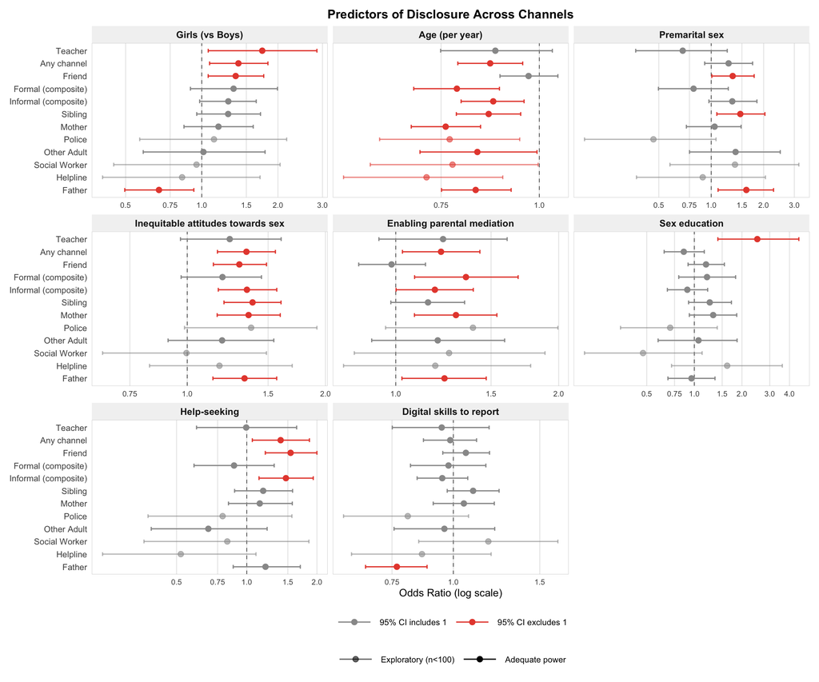

Figure 1: Predictors of disclosure across channels (forest plot)

```r
# forest plot
forest_plot <- ggplot(forest_df, aes(x = OR, y = channel_label)) +
  geom_vline(xintercept = 1, linetype = "dashed", color = "grey40", linewidth = 0.4) +
  geom_errorbarh(
    aes(xmin = OR_lwr, xmax = OR_upr, color = sig, alpha = exploratory),
    height = 0.3,
    linewidth = 0.6
  ) +
  geom_point(aes(color = sig, alpha = exploratory), size = 2.5) +
  facet_wrap(~ Predictors, scales = "free_x", ncol = 3) +
  scale_color_manual(
    values = c(`TRUE` = "#E74C3C", `FALSE` = "grey60"),
    labels = c(`TRUE` = "95% CI excludes 1", `FALSE` = "95% CI includes 1"),
    name = NULL
  ) +
  scale_alpha_manual(
    values = c(`TRUE` = 0.6, `FALSE` = 1.0),
    breaks = c(TRUE, FALSE),
    labels = c(`TRUE` = "Exploratory (n<100)", `FALSE` = "Adequate power"),
    na.value = 1.0,
    name = NULL
  ) +
  scale_x_continuous(
    trans = "log10",
    breaks = c(0.5, 0.75, 1, 1.5, 2, 3, 4),
    labels = c("0.5", "0.75", "1.0", "1.5", "2.0", "3.0", "4.0")
  ) +
  labs(
    x = "Odds Ratio (log scale)",
    y = NULL,
    title = "Predictors of Disclosure Across Channels"
  ) +
  theme_minimal(base_size = 11) +
  theme(
    legend.position = "bottom",
    legend.box = "vertical",
    legend.key.width = unit(1.5, "cm"),
    panel.grid.minor = element_blank(),
    panel.grid.major.y = element_blank(),
    panel.border = element_rect(fill = NA, color = "grey80", linewidth = 0.3),
    strip.text = element_text(face = "bold", size = 10),
    strip.background = element_rect(fill = "grey95", color = NA),
    axis.text.y = element_text(size = 9),
    axis.text.x = element_text(size = 8),
    plot.title = element_text(face = "bold", size = 13, hjust = 0.5),
    plot.margin = margin(10, 10, 10, 10)
  )

forest_plot

ggsave(
  "forest_channels.png",
  forest_plot,
  width = 12,
  height = 10,
  dpi = 300,
  bg = "white"
)
```

## Combined Table (All Channels Odds Ratios)

```r
coef_table_all <- or_results %>%
  mutate(
    channel_clean = case_when(
      channel == "toldall"      ~ "Any",
      channel == "toldformal"   ~ "Formal",
      channel == "toldinformal" ~ "Informal",
      channel %in% names(channel_labels) ~ channel_labels[channel],
      TRUE ~ channel
    )
  ) %>%
  select(channel_clean, Predictors, cell) %>%
  pivot_wider(
    names_from  = channel_clean,
    values_from = cell
  ) %>%
  select(
    Predictors,
    Any, Formal, Informal,                      # composite
    Police, Helpline, `Social Worker`, Teacher, # formal channels
    Mother, Father, Sibling, Friend, `Other Adult` # informal channels
  )

kable(
  coef_table_all,
  booktabs = TRUE,
  escape   = FALSE,
  align    = c("l", rep("r", 12))
) %>%
  kable_styling(
    latex_options = c("striped", "hold_position", "scale_down"),
    font_size     = 6,
    full_width    = TRUE
  ) %>%
  add_header_above(
    c(" " = 1, "Composite" = 3, "Formal" = 4, "Informal" = 5)
  ) %>%
  footnote(
    general = c(
      "**Bold** indicates 95% CI excludes 1.0; † indicates substantive effect (OR ≥ 1.5 or ≤ 0.67)",
      "Police, Helpline, and Social Worker have limited sample sizes (EPV < 10)."
    ),
    general_title      = "Note:",
    footnote_as_chunk  = TRUE
  )
```

Table 5: Predictors of disclosure across all channels (odds ratios with 95% CIs)

| Predictors | Composite Any | Composite Formal | Composite Informal | Formal Police | Formal Helpline | Formal Social Worker | Formal Teacher | Informal Mother | Informal Father | Informal Sibling | Informal Friend | Informal Other Adult |
| --- | --- | --- | --- | --- | --- | --- | --- | --- | --- | --- | --- | --- |
| Intercept | **1.66 (1.06–2.43)†** | **0.09 (0.05–0.15)†** | **1.59 (1.08–2.22)†** | **0.01 (0.00–0.05)†** | **0.02 (0.00–0.07)†** | **0.01 (0.00–0.04)†** | **0.03 (0.01–0.08)†** | **0.09 (0.05–0.16)†** | **0.23 (0.12–0.47)†** | **0.15 (0.09–0.26)†** | **0.58 (0.35–0.95)†** | **0.03 (0.01–0.09)†** |
| Girls (vs Boys) | **1.40 (1.07–1.83)** | 1.34 (0.90–1.99) | 1.27 (0.98–1.64) | 1.12 (0.57–2.17) | 0.84 (0.41–1.70) | 0.95 (0.45–2.04) | **1.73 (1.06–2.85)†** | 1.16 (0.85–1.60) | **0.68 (0.50–0.93)** | 1.27 (0.96–1.71) | **1.36 (1.06–1.76)** | 1.02 (0.59–1.78) |
| Age (per year) | **0.87 (0.79–0.95)** | **0.79 (0.69–0.89)** | **0.87 (0.80–0.96)** | **0.77 (0.63–0.94)** | **0.72 (0.56–0.90)** | **0.78 (0.61–1.00)** | 0.88 (0.75–1.04) | **0.76 (0.69–0.84)** | **0.83 (0.75–0.92)** | **0.86 (0.78–0.95)** | 0.97 (0.89–1.06) | **0.83 (0.71–0.99)** |
| Premarital sex | 1.26 (0.92–1.73) | 0.79 (0.50–1.25) | 1.32 (0.97–1.83) | 0.47 (0.19–1.07) | 0.89 (0.37–2.05) | 1.37 (0.58–3.18) | 0.69 (0.37–1.24) | 1.05 (0.72–1.48) | **1.59 (1.09–2.28)†** | **1.47 (1.08–2.03)** | **1.33 (1.01–1.76)** | 1.38 (0.75–2.49) |
| Inequitable attitudes towards sex | **1.35 (1.16–1.56)** | 1.19 (0.97–1.45) | **1.35 (1.17–1.57)** | 1.38 (0.99–1.92) | 1.18 (0.83–1.69) | 1.00 (0.65–1.49) | 1.24 (0.97–1.60) | **1.36 (1.16–1.59)** | **1.33 (1.14–1.57)** | **1.39 (1.20–1.60)** | **1.30 (1.14–1.49)** | 1.19 (0.91–1.54) |
| Enabling parental mediation | **1.21 (1.03–1.43)** | **1.35 (1.08–1.68)** | **1.18 (1.00–1.39)** | 1.39 (0.96–1.99) | 1.18 (0.80–1.78) | 1.25 (0.84–1.89) | 1.22 (0.93–1.61) | **1.29 (1.08–1.54)** | **1.23 (1.03–1.47)** | 1.15 (0.98–1.34) | 0.98 (0.85–1.13) | 1.20 (0.90–1.59) |
| Sex education | 0.86 (0.64–1.16) | 1.20 (0.80–1.82) | 0.90 (0.68–1.21) | 0.70 (0.34–1.40) | 1.61 (0.72–3.60) | 0.47 (0.20–1.12) | **2.50 (1.41–4.58)†** | 1.32 (0.93–1.85) | 0.96 (0.68–1.35) | 1.25 (0.92–1.72) | 1.19 (0.91–1.55) | 1.06 (0.59–1.86) |
| Help-seeking | **1.40 (1.06–1.86)** | 0.88 (0.59–1.31) | **1.47 (1.13–1.93)** | 0.79 (0.38–1.56) | 0.52 (0.24–1.10) | 0.83 (0.36–1.85) | 0.99 (0.61–1.64) | 1.14 (0.83–1.57) | 1.20 (0.87–1.70) | 1.18 (0.89–1.57) | **1.54 (1.20–2.00)†** | 0.68 (0.39–1.22) |
| Digital skills to report | 0.99 (0.87–1.12) | 0.98 (0.82–1.16) | 0.95 (0.84–1.07) | 0.81 (0.60–1.07) | 0.86 (0.62–1.19) | 1.18 (0.85–1.63) | 0.95 (0.75–1.18) | 1.05 (0.91–1.21) | **0.77 (0.66–0.88)** | 1.10 (0.97–1.24) | 1.06 (0.95–1.19) | 0.96 (0.76–1.21) |

Note: **Bold** indicates 95% CI excludes 1.0; † indicates substantive effect (OR ≥ 1.5 or ≤ 0.67) Police, Helpline, and Social Worker have limited sample sizes (EPV < 10).

## Correlations between predictors

```r
# plot weighted correlations for predictors
predictor_corr <- function(data, rhs, w = NULL,
                           tl_cex = 0.9, num_cex = 0.95, digits = 2,
                           clean_labels = NULL) {

  X <- model.matrix(as.formula(rhs), data = data)[, -1, drop = FALSE]
  X <- X[, apply(X, 2, function(z) sd(z, na.rm = TRUE) > 0), drop = FALSE]

  # rename columns again
  if (!is.null(clean_labels)) {
    for (nm in names(clean_labels)) {
      if (nm %in% colnames(X)) {
        colnames(X)[colnames(X) == nm] <- clean_labels[[nm]]
      }
    }
  }

  w <- if (is.null(w)) rep(1, nrow(X)) else w
  w <- ifelse(is.finite(w) & w > 0, w, 1)

  ok <- complete.cases(X)
  X  <- X[ok, , drop = FALSE]
  w  <- w[ok]

  Xs <- scale(X, center = TRUE, scale = TRUE)
  Xw <- sweep(Xs, 1, sqrt(w), `*`)
  M  <- cov2cor(crossprod(Xw) / sum(w))

  col_div <- colorRampPalette(c("#1b6ca8", "#f7f7f7", "#b22222"))(240)
  op <- par(mar = c(1.2, 1.2, 1.2, 1.2))
  on.exit(par(op), add = TRUE)

  corrplot(
    M,
    method        = "color",
    type          = "upper",
    tl.col        = "black",
    tl.cex        = tl_cex,
    tl.srt        = 45,
    cl.cex        = 0.9,
    cl.align      = "c",
    cl.ratio      = 0.15,
    col           = col_div,
    addgrid.col   = "white",
    number.cex    = num_cex,
    number.digits = digits,
    addCoef.col   = "black",
    diag          = FALSE,
    outline       = TRUE
  )

  invisible(M)
}
```

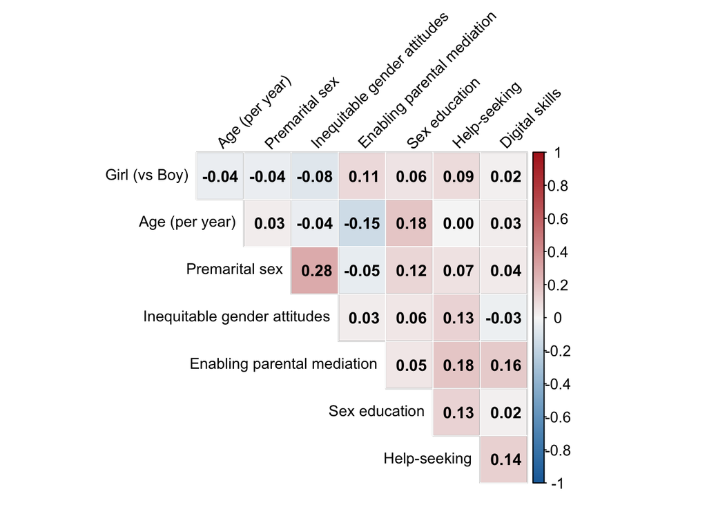

```r
# predictor correlations
rhs <- "~ sex + age + presex + nindex + parentmediate + sexed + helpseeking + digitalskills"
corr_preds <- predictor_corr(d_report, rhs, w = d_report$wgt_scaled, clean_labels = clean_labels)
```

```r
# save
png("figure_corr.pdf",
    width = 6,
    height = 4,
    units = "in",
    res = 300
    )

corr_preds <- predictor_corr(
  d_report,
  rhs,
  w = d_report$wgt_scaled,
  clean_labels = clean_labels
)
dev.off()
```

## (4) Random slopes sensitivity analysis (exploratory, not pre-registered)

```r
# age
fit_report_all_age <- brm(
  toldall | weights(wgt_scaled) ~
    sex + age + presex + nindex +
    parentmediate + sexed + helpseeking + digitalskills +
    (1 + age | COUNTRY),
  data   = d_report,
  family = bernoulli(),
  backend = "cmdstanr",
  chains = 4,
  cores  = 4,
  iter   = 2000,
  warmup = 1000,
  threads = threading(2),
  control = list(adapt_delta = 0.99),
  seed = 123,
  file = "models/brm-disclosure-all-age-cmd"
)

# gender
fit_report_all_sex <- brm(
  toldall | weights(wgt_scaled) ~
    sex + age + presex + nindex +
    parentmediate + sexed + helpseeking + digitalskills +
    (1 + sex | COUNTRY),
  data   = d_report,
  family = bernoulli(),
  backend = "cmdstanr",
  chains = 4,
  cores  = 4,
  iter   = 2000,
  warmup = 1000,
  threads = threading(2),
  control = list(adapt_delta = 0.99),
  seed = 123,
  file = "models/brm-disclosure-all-sex-cmd"
)

# premartial sex
fit_report_all_presex <- brm(
  toldall | weights(wgt_scaled) ~
    sex + age + presex + nindex +
    parentmediate + sexed + helpseeking + digitalskills +
    (1 + presex | COUNTRY),
  data   = d_report,
  family = bernoulli(),
  backend = "cmdstanr",
  chains = 4,
  cores  = 4,
  iter   = 2000,
  warmup = 1000,
  threads = threading(2),
  control = list(adapt_delta = 0.99),
  seed = 123,
  file = "models/brm-disclosure-all-presex-cmd"
)

# inequitable gender attitudes
fit_report_all_nindex <- brm(
  toldall | weights(wgt_scaled) ~
    sex + age + presex + nindex +
    parentmediate + sexed + helpseeking + digitalskills +
    (1 + nindex | COUNTRY),
  data   = d_report,
  family = bernoulli(),
  backend = "cmdstanr",
  chains = 4,
  cores  = 4,
  iter   = 2000,
  warmup = 1000,
  threads = threading(2),
  control = list(adapt_delta = 0.99),
  seed = 123,
  file = "models/brm-disclosure-all-nindex -cmd"
)

# parentmediate
fit_report_all_parentmediate <- brm(
  toldall | weights(wgt_scaled) ~
    sex + age + presex + nindex +
    parentmediate + sexed + helpseeking + digitalskills +
    (1 +  parentmediate | COUNTRY),
  data   = d_report,
  family = bernoulli(),
  backend = "cmdstanr",
  chains = 4,
  cores  = 4,
  iter   = 2000,
  warmup = 1000,
  threads = threading(2),
  control = list(adapt_delta = 0.99),
  seed = 123,
  file = "models/brm-disclosure-all-parentmediate-cmd"
)

# sex education
fit_report_all_sexed <- brm(
  toldall | weights(wgt_scaled) ~
    sex + age + presex + nindex +
    parentmediate + sexed + helpseeking + digitalskills +
    (1 + sexed | COUNTRY),
  data   = d_report,
  family = bernoulli(),
  backend = "cmdstanr",
  chains = 4,
  cores  = 4,
  iter   = 2000,
  warmup = 1000,
  threads = threading(2),
  control = list(adapt_delta = 0.99),
  seed = 123,
  file = "models/brm-disclosure-all-sexed-cmd"
)

# helpseeking
fit_report_all_helpseeking <- brm(
  toldall | weights(wgt_scaled) ~
    sex + age + presex + nindex +
    parentmediate + sexed + helpseeking + digitalskills +
    (1 + helpseeking | COUNTRY),
  data   = d_report,
  family = bernoulli(),
  backend = "cmdstanr",
  chains = 4,
  cores  = 4,
  iter   = 2000,
  warmup = 1000,
  threads = threading(2),
  control = list(adapt_delta = 0.99),
  seed = 123,
  file = "models/brm-disclosure-all-helpseeking-cmd"
)

# digital skills
fit_report_all_digitalskills <- brm(
  toldall | weights(wgt_scaled) ~
    sex + age + presex + nindex +
    parentmediate + sexed + helpseeking + digitalskills +
    (1 + digitalskills | COUNTRY),
  data   = d_report,
  family = bernoulli(),
  backend = "cmdstanr",
  chains = 4,
  cores  = 4,
  iter   = 2000,
  warmup = 1000,
  threads = threading(2),
  control = list(adapt_delta = 0.99),
  seed = 123,
  file = "models/brm-disclosure-all-digitalskills-cmd"
)
```

### LOO disclosure models

Now we estimate a model’s predictive accuracy from out-of-sample data using Pareto Smoothed Importance Sampling (PSIS-LOO)

```r
# loo
loo_all_complete <-  loo(fit_report_all)
loo_age           <- loo(fit_report_all_age)
loo_sex           <- loo(fit_report_all_sex)
loo_presex        <- loo(fit_report_all_presex)
loo_nindex        <- loo(fit_report_all_nindex)
loo_parentmediate <- loo(fit_report_all_parentmediate)
loo_sexed         <- loo(fit_report_all_sexed)
loo_helpseeking   <- loo(fit_report_all_helpseeking)
loo_digitalskills <- loo(fit_report_all_digitalskills)

# loo compare
loo_disclosuremodels <- loo::loo_compare(
  loo_all_complete,
  loo_age,
  loo_sex,
  loo_presex,
  loo_nindex,
  loo_parentmediate,
  loo_sexed,
  loo_helpseeking,
  loo_digitalskills
)

# relabel
loo_models <- list(
  "Full model (RI)"                        = loo_all_complete,
  "Age (random slope)"                     = loo_age,
  "Gender (random slope)"                  = loo_sex,
  "Premarital sex (random slope)"          = loo_presex,
  "Inequitable attitudes (random slope)"   = loo_nindex,
  "Parental mediation (random slope)"      = loo_parentmediate,
  "Sex education (random slope)"           = loo_sexed,
  "Help-seeking (random slope)"            = loo_helpseeking,
  "Digital skills (random slope)"          = loo_digitalskills
)
```

## Pareto-k summary for each model

We check PSIS-LOO diagnostics across several fitted models. The Pareto-k values flag whether the LOO approximation is reliable for each observation

```r
# pareto summary
pk_summary <- function(x, label) {
  k <- pareto_k_values(x)

  data.frame(
    Model      = label,
    `max k`    = round(max(k), 2),
    `n > 0.7`  = sum(k > 0.7),
    check.names = FALSE
  )
}

paret_disclosure <- map_dfr(
  names(loo_models),
  ~ pk_summary(loo_models[[.x]], .x)
)

knitr::kable(
  paret_disclosure,
  caption = "PSIS-LOO Pareto-k diagnostics (k < 0.7 acceptable).",
  align   = "lrr"
)
```

PSIS-LOO Pareto-k diagnostics (k < 0.7 acceptable).

| Model | max k | n > 0.7 |
| --- | --- | --- |
| Full model (RI) | 0.28 | 0 |
| Age (random slope) | 0.52 | 0 |
| Gender (random slope) | 0.40 | 0 |
| Premarital sex (random slope) | 0.50 | 0 |
| Inequitable attitudes (random slope) | 0.53 | 0 |
| Parental mediation (random slope) | 0.43 | 0 |
| Sex education (random slope) | 0.49 | 0 |
| Help-seeking (random slope) | 0.42 | 0 |
| Digital skills (random slope) | 0.37 | 0 |

## Plot LOO disclosure models

Finally, we plot ΔELPD with standard-error bars

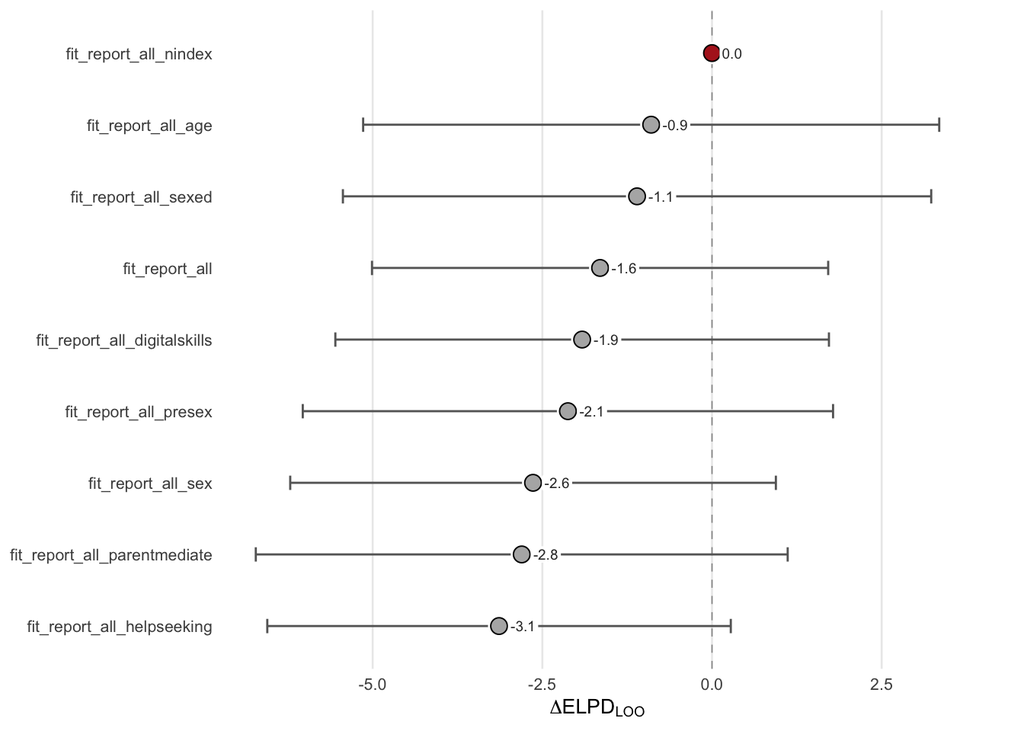

```r
# loo comparison data
disclosurel_df <- as.data.frame(loo_disclosuremodels) %>%
  rownames_to_column("Model_raw") %>%
  transmute(
    Model_clean = str_replace_all(
      str_remove_all(Model_raw, "^loo\\(|\\)$"),
      "^x=",
      ""
    ),
    elpd_diff,
    se_diff
  )

#better labels
idx <- match(disclosurel_df$Model_clean, names(loo_models))
disclosurel_df$Model <- ifelse(
  is.na(idx),
  disclosurel_df$Model_clean,
  loo_models[idx]
)

# identify best model
best_model <- disclosurel_df %>%
  filter(elpd_diff == 0) %>%
  pull(Model)

# plot elpd with se bars
loo_disclosure <- ggplot(
  disclosurel_df,
  aes(x = reorder(Model, elpd_diff), y = elpd_diff)
) +
  geom_hline(
    yintercept = 0,
    linetype   = "dashed",
    color      = "grey60",
    linewidth  = 0.3
  ) +
  geom_errorbar(
    aes(ymin = elpd_diff - se_diff, ymax = elpd_diff + se_diff),
    width     = 0.2,
    linewidth = 0.5,
    color     = "grey40"
  ) +
  geom_point(
    size  = 4.5,
    shape = 21,
    fill  = "white",
    color = "white"
  ) +
  geom_point(
    aes(fill = Model == best_model),
    size  = 3.5,
    shape = 21,
    color = "black",
    stroke = 0.5
  ) +
  geom_label(
    aes(label = sprintf("%.1f", elpd_diff)),
    hjust         = -0.3,
    size          = 2.5,
    label.padding = unit(0.15, "lines"),
    label.size    = 0,
    fill          = "white",
    color         = "grey20"
  ) +
  coord_flip() +
  labs(
    x = NULL,
    y = expression(Delta * ELPD[LOO])
  ) +
  scale_fill_manual(
    values = c("TRUE" = "firebrick", "FALSE" = "grey70"),
    guide  = "none"
  ) +
  theme_minimal(base_size = 10) +
  theme(
    plot.margin       = margin(5, 25, 5, 5),
    panel.grid.minor  = element_blank(),
    panel.grid.major.y = element_blank()
  )

loo_disclosure
```

```r
ggsave(
  "figure_loo.png",
  loo_disclosure,
  width  = 6,
  height = 4,
  dpi    = 300
)
```

## LOO disclosure models (table)

```r
loo_output <- disclosurel_df  %>%
  select(Model, elpd_diff, se_diff)

loo_tabdisclose <- loo_output %>%
  knitr::kable(
    digits = 2,
    col.names = c("Model", "ΔELPD", "SE"),
    caption = "."
  ) %>%
  kable_styling(full_width = FALSE, bootstrap_options = c("striped", "hover"))

loo_tabdisclose
```

.

| Model | ΔELPD | SE |
| --- | --- | --- |
| fit_report_all_nindex | 0.0 | 0.0 |
| fit_report_all_age | -0.9 | 4.2 |
| fit_report_all_sexed | -1.1 | 4.3 |
| fit_report_all | -1.6 | 3.4 |
| fit_report_all_digitalskills | -1.9 | 3.6 |
| fit_report_all_presex | -2.1 | 3.9 |
| fit_report_all_sex | -2.6 | 3.6 |
| fit_report_all_parentmediate | -2.8 | 3.9 |
| fit_report_all_helpseeking | -3.1 | 3.4 |